# Arranging brain views

```r
library(ggseg)
library(ggplot2)
```

A brain atlas typically has several views – lateral and medial for cortical atlases, or axial, coronal, and sagittal slices for subcortical and tract atlases. `position_brain()` controls how those views are arranged in the final plot.

The function works differently depending on the atlas type, so this vignette covers cortical and subcortical/tract atlases separately.

## Cortical atlases

Cortical atlases like `dk` have two layout dimensions: **hemi** (left or right) and **view** (lateral, medial, etc.). The formula syntax mirrors `facet_grid()` – left side is rows, right side is columns:

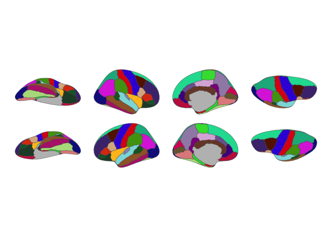

Cortical atlas with hemispheres as rows and views as columns.

```r
ggplot() +
  geom_brain(
    atlas = dk(),
    position = position_brain(hemi ~ view),
    show.legend = FALSE
  ) +
  theme_void()
```

Flip the formula to transpose the layout:

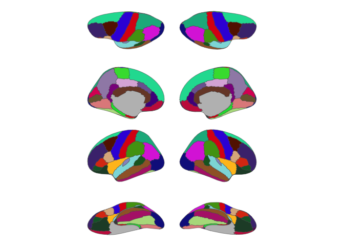

Transposed layout with views as rows and hemispheres as columns.

```r
ggplot() +
  geom_brain(
    atlas = dk(),
    position = position_brain(view ~ hemi),
    show.legend = FALSE
  ) +
  theme_void()
```

### Stacking all views

Use `.` with `+` to collapse everything into a single row or column. This is handy for compact figures:

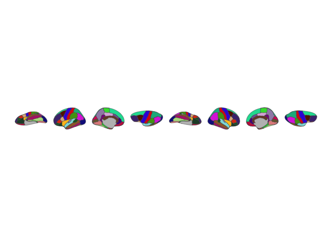

All brain views stacked in a single row.

```r
ggplot() +
  geom_brain(
    atlas = dk(),
    position = position_brain(. ~ hemi + view),
    show.legend = FALSE
  ) +
  theme_void()
```

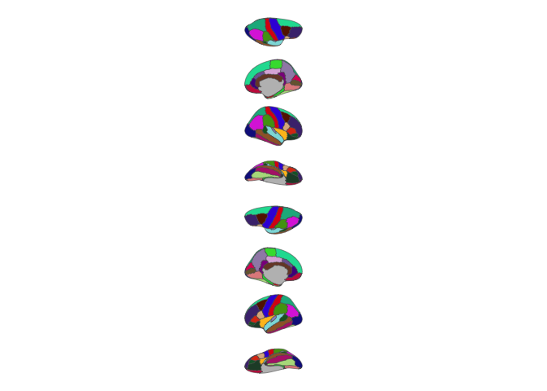

All brain views stacked in a single column.

```r
ggplot() +
  geom_brain(
    atlas = dk(),
    position = position_brain(hemi + view ~ .),
    show.legend = FALSE
  ) +
  theme_void()
```

## Subcortical and tract atlases

Subcortical atlases like `aseg` and tract atlases like `tracula` don’t have the hemisphere/view pairing that cortical atlases do. Their views are individual slices (e.g. `"axial_3"`, `"sagittal"`). That opens up a different set of positioning tools.

### Horizontal and vertical

The simplest options. `"horizontal"` is the default:

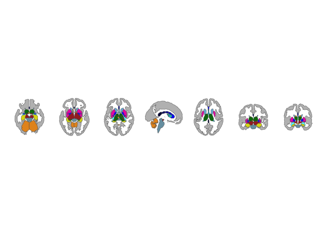

Subcortical atlas views arranged horizontally.

```r
ggplot() +
  geom_brain(
    atlas = aseg(),
    position = position_brain("horizontal"),
    show.legend = FALSE
  ) +
  theme_void()
```

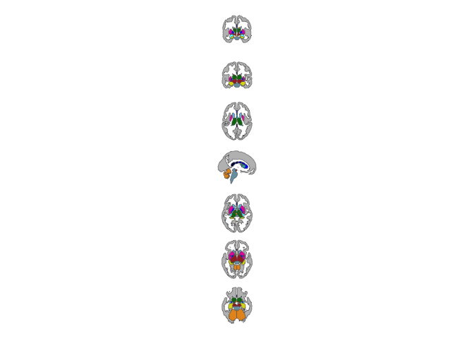

Subcortical atlas views arranged vertically.

```r
ggplot() +
  geom_brain(
    atlas = aseg(),
    position = position_brain("vertical"),
    show.legend = FALSE
  ) +
  theme_void()
```

### Grid layouts

When you have many views, a grid keeps things readable. Specify `nrow`, `ncol`, or both:

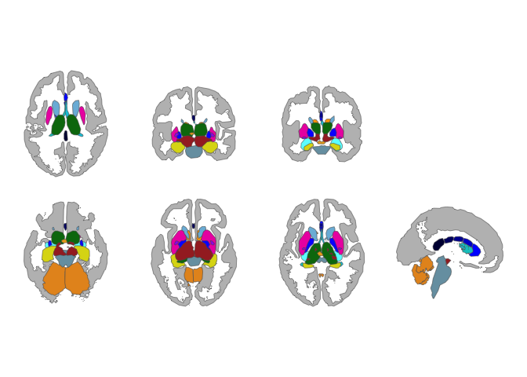

Subcortical atlas views in a two-row grid.

```r
ggplot() +
  geom_brain(
    atlas = aseg(),
    position = position_brain(nrow = 2),
    show.legend = FALSE
  ) +
  theme_void()
```

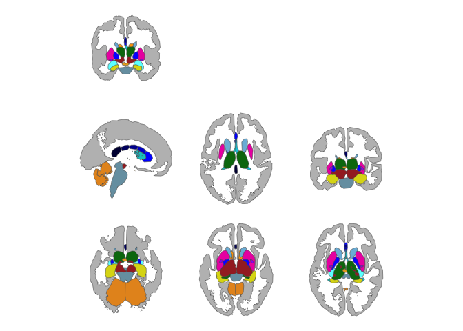

Subcortical atlas views in a three-column grid.

```r
ggplot() +
  geom_brain(
    atlas = aseg(),
    position = position_brain(ncol = 3),
    show.legend = FALSE
  ) +
  theme_void()
```

### Picking specific views

The `views` parameter lets you select which views to include and in what order. Check what’s available with `ggseg.formats::atlas_views()`:

```r
ggseg.formats::atlas_views(aseg())
```

```
#> [1] "axial_3"   "axial_4"   "axial_5"   "sagittal"  "axial_6"   "coronal_1"
#> [7] "coronal_2"
```

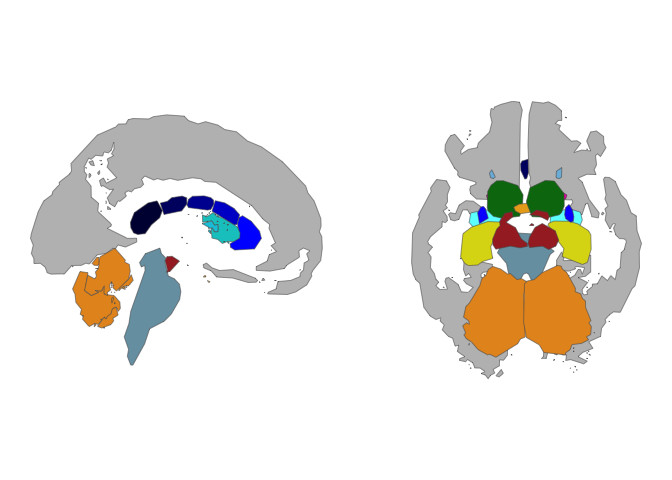

A subset of subcortical views selected by name.

```r
ggplot() +
  geom_brain(
    atlas = aseg(),
    position = position_brain(
      views = c("sagittal", "axial_3", "coronal_3")
    ),
    show.legend = FALSE
  ) +
  theme_void()
```

Combine `views` with `nrow` or `ncol` for a custom grid:

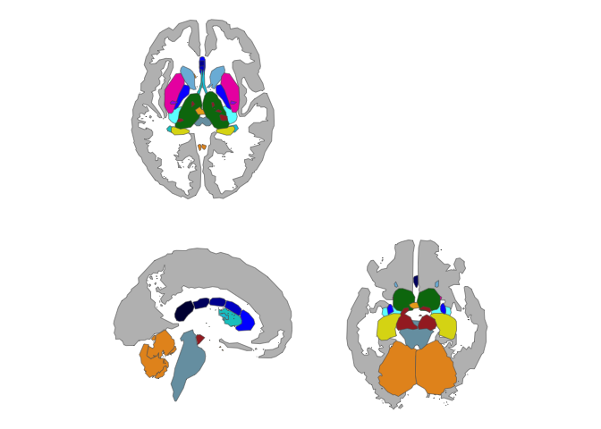

Custom two-row grid with selected subcortical views.

```r
ggplot() +
  geom_brain(
    atlas = aseg(),
    position = position_brain(
      views = c("sagittal", "axial_3", "axial_5", "coronal_3"),
      nrow = 2
    ),
    show.legend = FALSE
  ) +
  theme_void()
```

### Grouping by slice type

The `type ~ .` formula groups views by their orientation – all axial slices together, all coronal slices together, and so on. The type is extracted from the view name (everything before the first underscore):

```r
ggplot() +
  geom_brain(
    atlas = aseg(),
    position = position_brain(type ~ .),
    show.legend = FALSE
  ) +
  theme_void()
```

[output not shown]

## Adding view labels

Use `annotate_brain()` to label each view with its name. For cortical atlases the label combines hemisphere and view (e.g. “left lateral”); for subcortical and tract atlases it uses the view name directly.

Store the `position_brain()` specification in an object so both layers share the same layout:

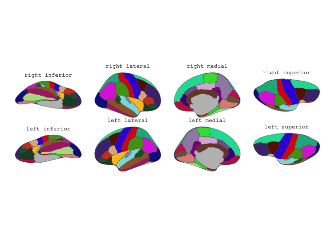

Cortical atlas with view labels.

```r
pos <- position_brain(hemi ~ view)
ggplot() +
  geom_brain(atlas = dk(), position = pos, show.legend = FALSE) +
  annotate_brain(atlas = dk(), position = pos) +
  theme_void()
```

It works with any positioning — horizontal, vertical, grid, and formula layouts:

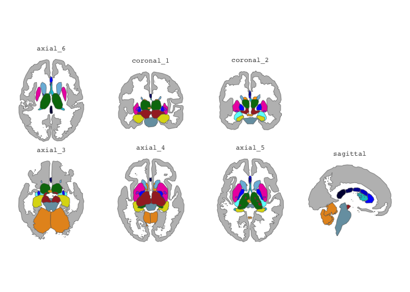

Subcortical atlas with view labels in a two-row grid.

```r
pos <- position_brain(nrow = 2)
ggplot() +
  geom_brain(atlas = aseg(), position = pos, show.legend = FALSE) +
  annotate_brain(atlas = aseg(), position = pos) +
  theme_void()
```

Labels sit a little above each view by default (`padding = 0.05`). Increase `padding` to push them further out, and tune the text through standard `annotate()` arguments:

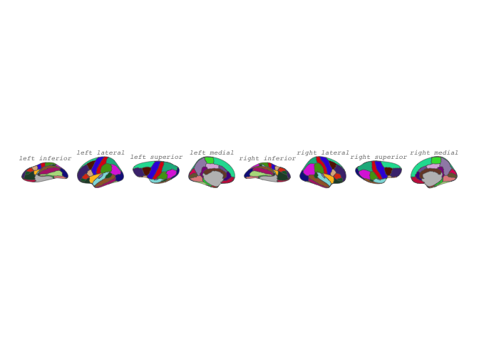

View labels with extra padding and custom styling.

```r
ggplot() +
  geom_brain(atlas = dk(), show.legend = FALSE) +
  annotate_brain(
    atlas = dk(),
    padding = 0.08,
    size = 2.5,
    colour = "grey50",
    fontface = "italic"
  ) +
  theme_void()
```

## Zooming in on regions of interest

For “focus” atlases – where only a few structures carry labels and the rest of the brain is grey context – `position_brain(zoom = ...)` crops each view onto the regions of interest, so they fill the panel while the surrounding context becomes a tidy grey frame. Every view keeps the same allotted cell.

### Focus on the regions in your data

`zoom = TRUE` focuses on whatever regions your data supplies values for (or, with no data, the atlas’s labelled regions):

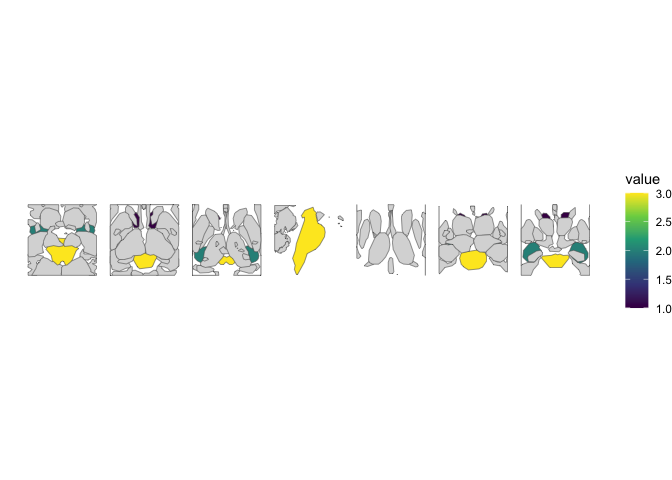

Each view zoomed onto the regions present in the supplied data.

```r
my_data <- data.frame(
  region = ggseg.formats::atlas_regions(aseg())[1:3],
  value = c(1, 2, 3)
)

ggplot() +
  geom_brain(
    atlas = aseg(),
    data = my_data,
    aes(fill = value),
    position = position_brain(zoom = TRUE)
  ) +
  scale_fill_viridis_c(na.value = "grey85") +
  theme_void()
```

### Name the focus regions explicitly

Pass a character vector to choose exactly which regions each view zooms onto, independent of any data you plot:

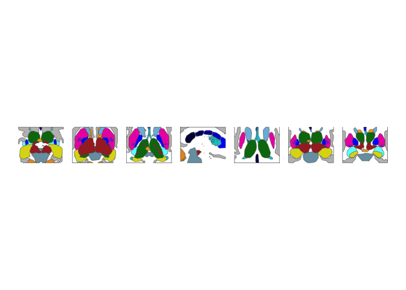

Zoom targeted at a named set of regions.

```r
focus <- c("Thalamus Proper", "Putamen", "Hippocampus")

ggplot() +
  geom_brain(
    atlas = aseg(),
    position = position_brain(zoom = focus),
    show.legend = FALSE
  ) +
  theme_void()
```

### Control the margin with `zoom_pad`

`zoom_pad` sets how much breathing room to leave around the focus regions, as a fraction of their size (5% by default). A smaller value crops tighter; a larger value keeps more context in frame:

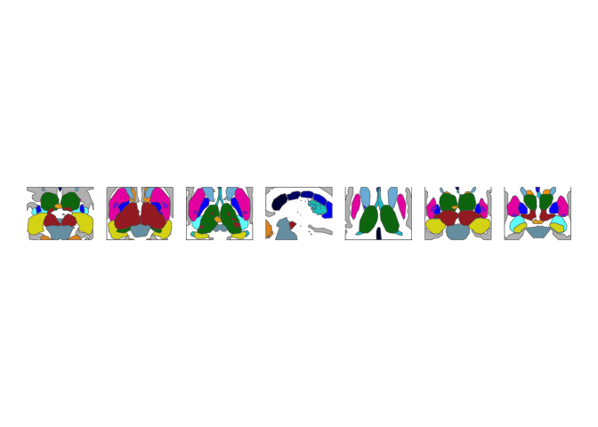

A tighter crop using a small zoom_pad.

```r
ggplot() +
  geom_brain(
    atlas = aseg(),
    position = position_brain(zoom = focus, zoom_pad = 0.01),
    show.legend = FALSE
  ) +
  theme_void()
```

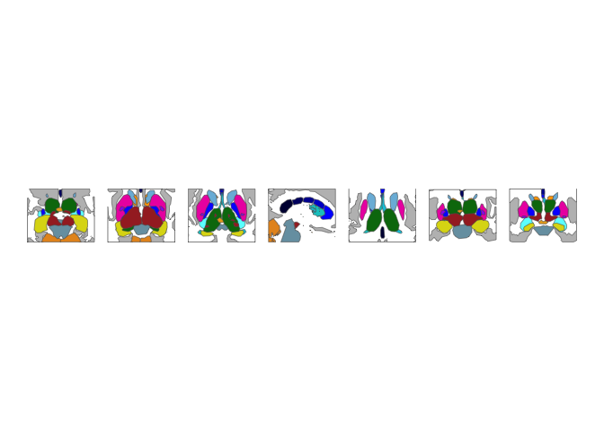

More surrounding context using a larger zoom_pad.

```r
ggplot() +
  geom_brain(
    atlas = aseg(),
    position = position_brain(zoom = focus, zoom_pad = 0.25),
    show.legend = FALSE
  ) +
  theme_void()
```

## Dropping the grey context

Set `context = FALSE` to remove the unlabelled context regions entirely. The remaining atlas regions are re-gathered into a tighter layout:

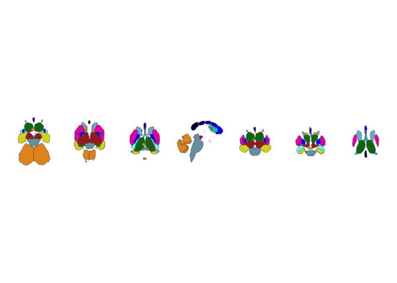

Subcortical atlas with the grey context regions removed.

```r
ggplot() +
  geom_brain(atlas = aseg(), context = FALSE, show.legend = FALSE) +
  theme_void()
```

## The sf workflow

If you work with brain atlases as sf objects – for example to layer `geom_sf()` text labels – `reposition_brain()` rearranges the sf data using the same arguments shown here. See `vignette("geom-sf")` for that workflow.